# Classification

2021-09-30

## Methods

In this tutorial you will learn about:

- Train/Test split
- Naive Bayes Classifier
- Importance of sampling
- Evaluation metrics

## Data

- We use a corpus of article titles and descriptions from the [New York Times front pages](http://www.amber-boydstun.com/supplementary-information-for-making-the-news.html).
- Our classification goal is to assign the story to a class of subject category.

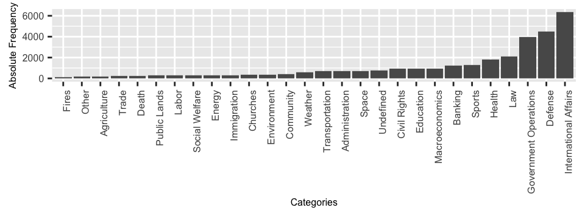

## Train-test split

[Jason Prownlee](https://machinelearningmastery.com/train-test-split-for-evaluating-machine-learning-algorithms/)

- The train-test split is a technique for evaluating the performance of a machine learning algorithm.
- It can be used for classification or regression problems and can be used for any supervised learning algorithm.
- Train Dataset: Used to fit the machine learning model.
- Test Dataset: Used to evaluate the fit machine learning model. The objective is to estimate the performance of the machine learning model on new data: data not used to train the model.

In our example: The trainingset consists of 3584 randomly sampled documents.

```r
set.seed(42)
train <- sample(1:5000, 3584, replace = FALSE)
head(train, 10)
```

```
##  [1] 2609 4069 2369 1098 1252  634 2097 3911  356 4261
```

```r
3584/dim(nytfrontpage)[1]
```

```
## [1] 0.1154862
```

## Naive Bayes Classifier

### Theory

Jurafsky and Martin (2018)

- A Naive Bayesian classifier makes a simplifying (naive) assumption about how the features interact.
- We represent a text document as if it was a bag-of-words.

### Train the model

[quanteda tutorial](https://tutorials.quanteda.io/machine-learning/nb/)

Next, we train the Naive Bayes classifier.

```r
tmod_nb <- textmodel_nb(dfmat_training, dfmat_training$majortopic)
```

## Evaluation

### Confusion Matrix

- The diagonal elements of a confusion matrix represent the number of points for which the predicted label is equal to the true label.
- The off-diagonal elements are those that are mislabeled by the classifier.
- The higher the diagonal values of the confusion matrix the better.

```
##             predicted_class
## actual_class    1    2    3    4    5    6    7    8    9   10
##           1   582    1    3    0    1    2    0    0    0    0
##           2     9  199   33    0    2   11    0    0    1    6
##           3    19   14 1046    3    2    8    1    1    0    4
##           4     7    2   27   10    0    1    1    0    0    4
##           5    23    3   17    0   27    0    0    0    0    9
##           6    15   14   17    0    1  518    0    0    0    1
##           7    14    7   21    0    0    6   38    2    0    9
##           8    19    0   29    0    0    4    0   30    0    6
##           9     1    2    5    0    1    1    0    0   70    1
##           10   20    3   22    0    7    3    0    0    0  223
```

## Metrics

- In order to evaluate the classifier, we calculate the metrics accuracy, precision and recall.
- Accuracy measures the fraction of all correct predictions.
- Precision: Out of the documents that the model predicts as category “Defense,” what is the fraction actually in the category “Defense?”
- Recall: What is fraction of documents in the category “Defense” that is correctly identified?

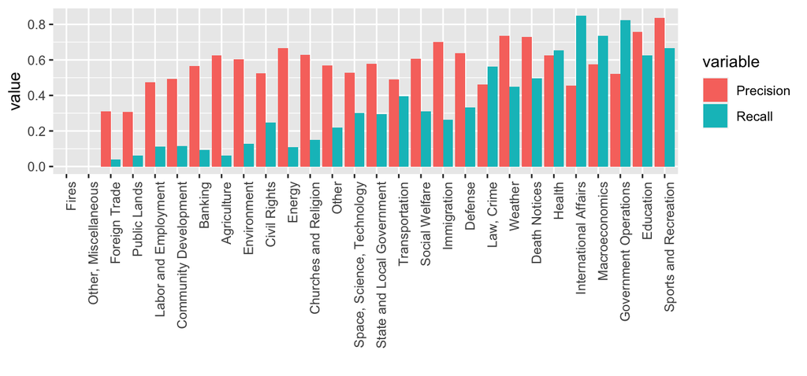

## Investigate poor classification

## Correlation with sample size

In order to find out why the classifier performs poorly for certain classes, we plot the share of category in the whole sample size against precision/recall.

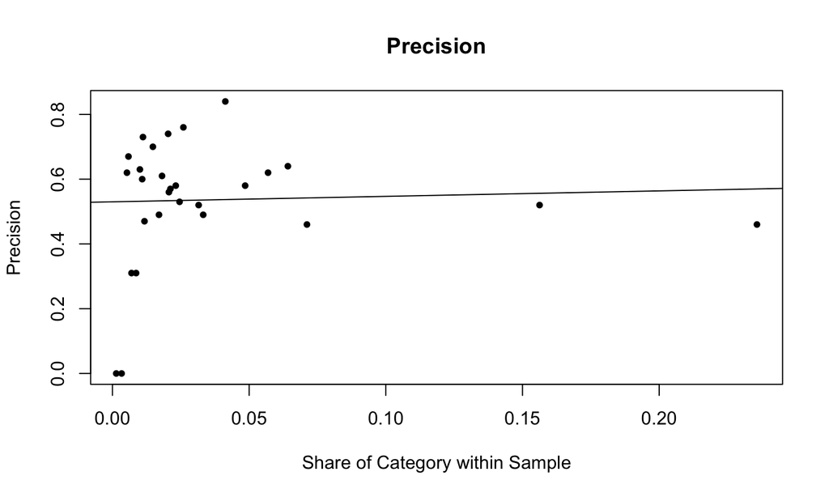

## Is the trainingset balanced?

The barplot shows that the trainingset is heavily unbalanced. The categories are far away from being uniformly distributed nor are the category sizes in the sample of the same size as in the original data set.

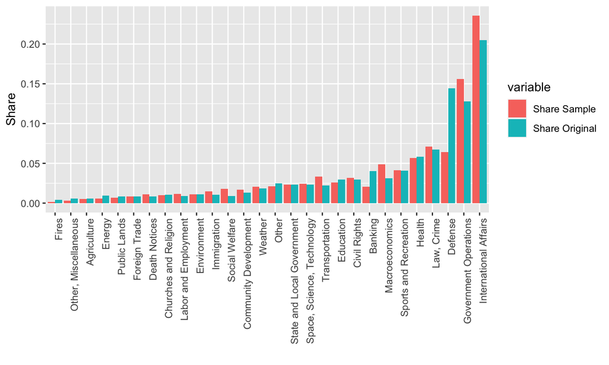

## Generate a balanced subset

We generate two different balanced subsets.

### Stratification

- Stratification is the process of dividing members of the population into homogeneous subgroups before sampling.
- Then simple random sampling or systematic sampling is applied within each stratum.

### Uniform distribution

Second, we assure balance via a uniform distribution.

## References

## It’s your turn! 👩‍💻 ~10’

Jurafsky, Daniel, and James H. Martin. 2018. “ Speech and Language Processing: An Introduction to Natural Language Processing, Computational Linguistics, and Speech Recognition.”